# Heatmaps of escapees CpG methylation levels

Gaja Matassa

Date: May 23, 2025

# 1. Environment setting

```r
library(dplyr)
```

```r
library(ggplot2)
library(scales)
library(gridExtra)
library(bsseq)
library(sechm)

source("../Methylation_helper.R")
InputFolder <- params$InputFolder
```

# 2. Loading data

Loading bsseq object

```r
bsseq_obj_escapees <- readRDS(paste0(InputFolder, "bsseq_obj_escapees_Hsu.rds"))
```

Loading annotated escapees

```r
AnnotatedEscapees <- readRDS("~/DataDir/7.EscapeesExploration/Output/EscapeesAnnotationAndFunctional_Hsu/AnnotatedEscapees.rds")
```

# 3. Heatmap

CpGs already filtered to be covered by ALL samples

We have 302502 CpGs.

Add annotation made in script 2.EscapeeAnnotationAndFunctional.Rmd

```r
AnnotatedEscapees_gr <- makeGRangesFromDataFrame(AnnotatedEscapees, keep.extra.columns = TRUE)
```

```r
m <- findOverlaps(rowRanges(bsseq_obj_escapees), AnnotatedEscapees_gr)

bsseq_obj_subset <- bsseq_obj_escapees[queryHits(m),]

rowData(bsseq_obj_subset)$ensembl_gene_id <- AnnotatedEscapees_gr[subjectHits(m), ]$ensembl_gene_id
```

Let’s show the **average** methylation levels. Instead of plotting for each row an escapee CpGs, I aggregate CpGs by ensembl gene id **averaging** the methylation levels.

## 3.1 5mCs + 5hmCs (WGBS)

```r
AvgMeth <- aggregate(assays(bsseq_obj_subset)$Meth_WGBS, list(rowData(bsseq_obj_subset)$ensembl_gene_id), mean, na.rm = T)
rownames(AvgMeth) <- AvgMeth$Group.1
AvgMeth <- AvgMeth[, -1]

rowDataSE <- rowData(bsseq_obj_subset)
rownames(rowDataSE) <- rowData(bsseq_obj_subset)$ensembl_gene_id
rowDataSE <- rowDataSE[rownames(AvgMeth), ]

SampleAnno <- colData(bsseq_obj_subset)

SE <- SummarizedExperiment(assays=AvgMeth, colData=SampleAnno, rowData = rowDataSE)

identical(colnames(assay(SE)), rownames(colData(SE))) #TRUE
```

```
## [1] TRUE
```

```r
# cellTypes_colors <- c(hiPSCs ="#dd1c77", iMeLCs ="#377eb8", hPGCLCs ="#4daf4a", hEGCLCs = "#ff7f00")
# colData(SE)$Type <- factor(colData(SE)$Type, levels = c("hiPSCs", "iMeLCs" , "hPGCLCs", "hEGCLCs"))
#
# metadata(SE)$anno_colors <- list(Type = cellTypes_colors,
#                                                GenomicRegion = c ("3' UTR" = "#FFADAD", "5' UTR" = "#FFD6A5", "Distal Intergenic" = "#FDFFB6", "Downstream (<=300bp)" = "#FFFFFC", "Exon" = "#9BF6FF", "Intron" = "#A0C4FF", "Promoter (<=1kb)" = "#BDB2FF", "Promoter (1-2kb)" = "#FFC6FF", "Promoter (2-3kb)" = "#CAFFBF"))
```

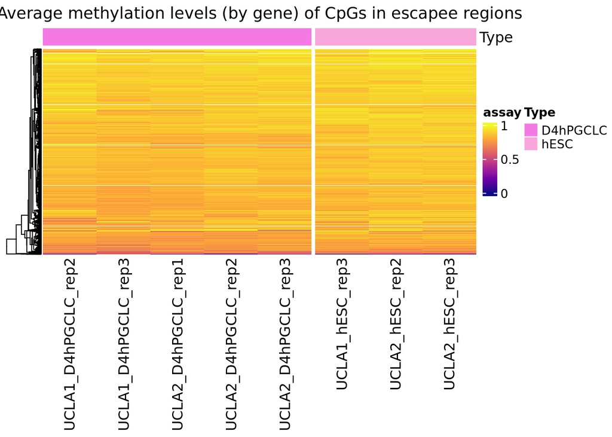

```r
break_coord <- assay(SE) %>% quantile(seq(0,1, by=0.1), na.rm =TRUE)
ExpCols <- viridisLite::plasma(length(seq(head(break_coord,1), tail(break_coord,1), by=0.2)))
sechm(SE, features = rownames(SE)[1:3000], hmcols=ExpCols, breaks=seq(head(break_coord,1), tail(break_coord,1), by=0.2), show_rownames=FALSE, show_colnames=TRUE, do.scale=FALSE, column_title = "Average methylation levels (by gene) of CpGs in escapee regions", top_annotation = c("Type"), row_title_rot = 0, cluster_rows = TRUE, gaps_at = "Type")
```

Let’s change the range of methylation

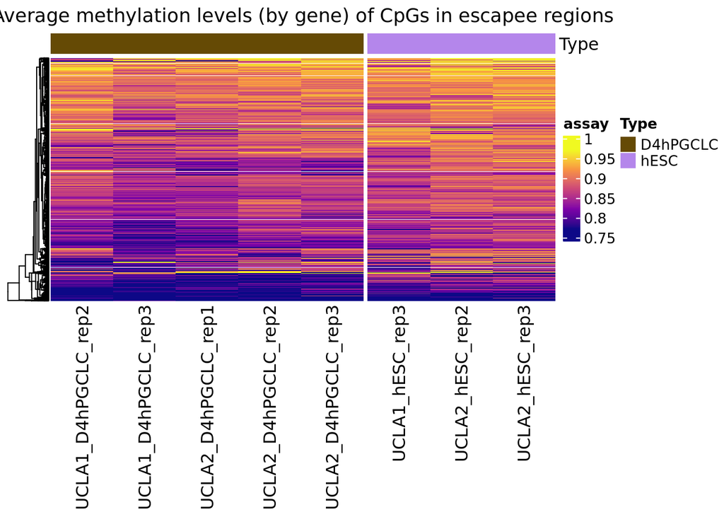

```r
break_coord <- assay(SE) %>% quantile(seq(0,1, by=0.1), na.rm =TRUE)
ExpCols <- viridisLite::plasma(length(seq(break_coord[2], tail(break_coord,1), by=0.05)))
sechm(SE, features = rownames(SE)[1:3000], hmcols=ExpCols, breaks=seq(break_coord[2], tail(break_coord,1), by=0.05), show_rownames=FALSE, show_colnames=TRUE, do.scale=FALSE, column_title = "Average methylation levels (by gene) of CpGs in escapee regions", top_annotation = c("Type"), row_title_rot = 0, cluster_rows = TRUE, gaps_at = "Type")
```

Let’s now show the **median** methylation levels. Instead of plotting for each row an escapee CpGs, I aggregate CpGs by ensembl gene id **doing the median** of the methylation levels.

```r
MedianMeth <- aggregate(assays(bsseq_obj_subset)$Meth_WGBS, list(rowData(bsseq_obj_subset)$ensembl_gene_id), median, na.rm = T)
rownames(MedianMeth) <- MedianMeth$Group.1
MedianMeth <- MedianMeth[, -1]

rowDataSE <- rowData(bsseq_obj_subset)
rownames(rowDataSE) <- rowData(bsseq_obj_subset)$ensembl_gene_id
rowDataSE <- rowDataSE[rownames(MedianMeth), ]

SampleAnno <- colData(bsseq_obj_subset)

SE <- SummarizedExperiment(assays=MedianMeth, colData=SampleAnno, rowData = rowDataSE)

identical(colnames(assay(SE)), rownames(colData(SE))) #TRUE
```

```
## [1] TRUE
```

```r
# cellTypes_colors <- c(hiPSCs ="#dd1c77", iMeLCs ="#377eb8", hPGCLCs ="#4daf4a", hEGCLCs = "#ff7f00")
# colData(SE)$Type <- factor(colData(SE)$Type, levels = c("hiPSCs", "iMeLCs" , "hPGCLCs", "hEGCLCs"))
#
# metadata(SE)$anno_colors <- list(Type = cellTypes_colors,
#                                                GenomicRegion = c ("3' UTR" = "#FFADAD", "5' UTR" = "#FFD6A5", "Distal Intergenic" = "#FDFFB6", "Downstream (<=300bp)" = "#FFFFFC", "Exon" = "#9BF6FF", "Intron" = "#A0C4FF", "Promoter (<=1kb)" = "#BDB2FF", "Promoter (1-2kb)" = "#FFC6FF", "Promoter (2-3kb)" = "#CAFFBF"))
```

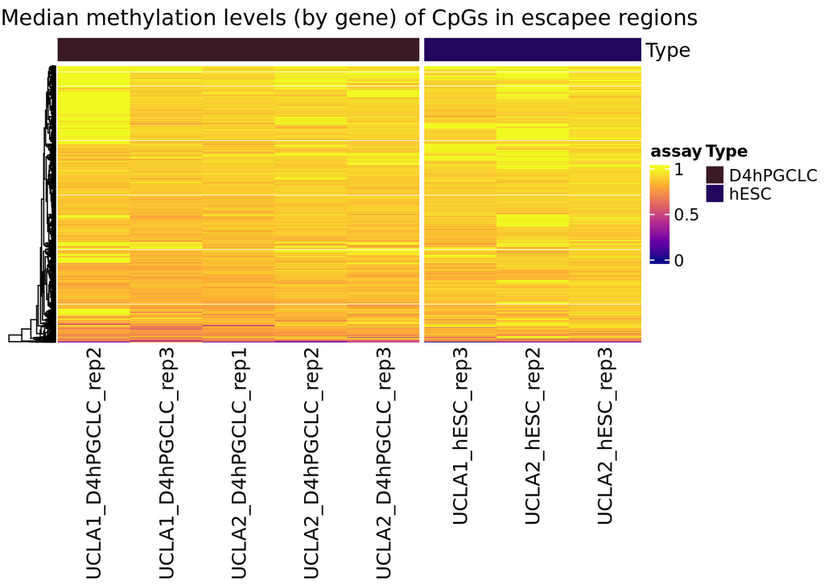

```r
break_coord <- assay(SE) %>% quantile(seq(0,1, by=0.1), na.rm =TRUE)
ExpCols <- viridisLite::plasma(length(seq(head(break_coord,1), tail(break_coord,1), by=0.2)))
sechm(SE, features = rownames(SE)[1:3000], hmcols=ExpCols, breaks=seq(head(break_coord,1), tail(break_coord,1), by=0.2), show_rownames=FALSE, show_colnames=TRUE, do.scale=FALSE, column_title = "Median methylation levels (by gene) of CpGs in escapee regions", top_annotation = c("Type"), row_title_rot = 0, cluster_rows = TRUE, gaps_at = "Type")
```

Let’s change the range of methylation (1st-10th deciles of methylation)

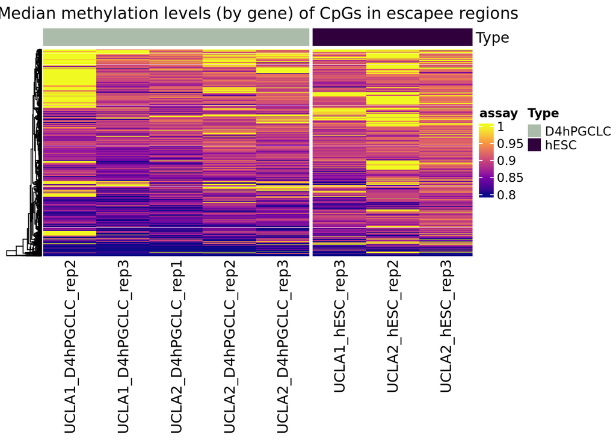

```r
break_coord <- assay(SE) %>% quantile(seq(0,1, by=0.1), na.rm =TRUE)
ExpCols <- viridisLite::plasma(length(seq(break_coord[2], tail(break_coord,1), by=0.05)))
sechm(SE, features = rownames(SE)[1:3000], hmcols=ExpCols, breaks=seq(break_coord[2], tail(break_coord,1), by=0.05), show_rownames=FALSE, show_colnames=TRUE, do.scale=FALSE, column_title = "Median methylation levels (by gene) of CpGs in escapee regions", top_annotation = c("Type"), row_title_rot = 0, cluster_rows = TRUE, gaps_at = "Type")
```

## 3.2 Only 5hmCs (bACEseq)

```r
AvgMeth <- aggregate(assays(bsseq_obj_subset)$Meth_hmC, list(rowData(bsseq_obj_subset)$ensembl_gene_id), mean, na.rm = T)
rownames(AvgMeth) <- AvgMeth$Group.1
AvgMeth <- AvgMeth[, -1]

rowDataSE <- rowData(bsseq_obj_subset)
rownames(rowDataSE) <- rowData(bsseq_obj_subset)$ensembl_gene_id
rowDataSE <- rowDataSE[rownames(AvgMeth), ]

SampleAnno <- colData(bsseq_obj_subset)

SE <- SummarizedExperiment(assays=AvgMeth, colData=SampleAnno, rowData = rowDataSE)

identical(colnames(assay(SE)), rownames(colData(SE))) #TRUE
```

```
## [1] TRUE
```

```r
# cellTypes_colors <- c(hiPSCs ="#dd1c77", iMeLCs ="#377eb8", hPGCLCs ="#4daf4a", hEGCLCs = "#ff7f00")
# colData(SE)$Type <- factor(colData(SE)$Type, levels = c("hiPSCs", "iMeLCs" , "hPGCLCs", "hEGCLCs"))
#
# metadata(SE)$anno_colors <- list(Type = cellTypes_colors,
#                                                GenomicRegion = c ("3' UTR" = "#FFADAD", "5' UTR" = "#FFD6A5", "Distal Intergenic" = "#FDFFB6", "Downstream (<=300bp)" = "#FFFFFC", "Exon" = "#9BF6FF", "Intron" = "#A0C4FF", "Promoter (<=1kb)" = "#BDB2FF", "Promoter (1-2kb)" = "#FFC6FF", "Promoter (2-3kb)" = "#CAFFBF"))
```

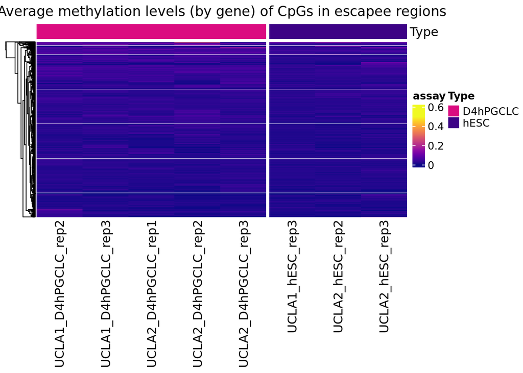

```r
break_coord <- assay(SE) %>% quantile(seq(0,1, by=0.1), na.rm =TRUE)
ExpCols <- viridisLite::plasma(length(seq(head(break_coord,1), tail(break_coord,1), by=0.05)))
sechm(SE, features = rownames(SE)[1:3000], hmcols=ExpCols, breaks=seq(head(break_coord,1), tail(break_coord,1), by=0.05), show_rownames=FALSE, show_colnames=TRUE, do.scale=FALSE, column_title = "Average methylation levels (by gene) of CpGs in escapee regions", top_annotation = c("Type"), row_title_rot = 0, cluster_rows = TRUE, gaps_at = "Type")
```

Let’s change the range of methylation

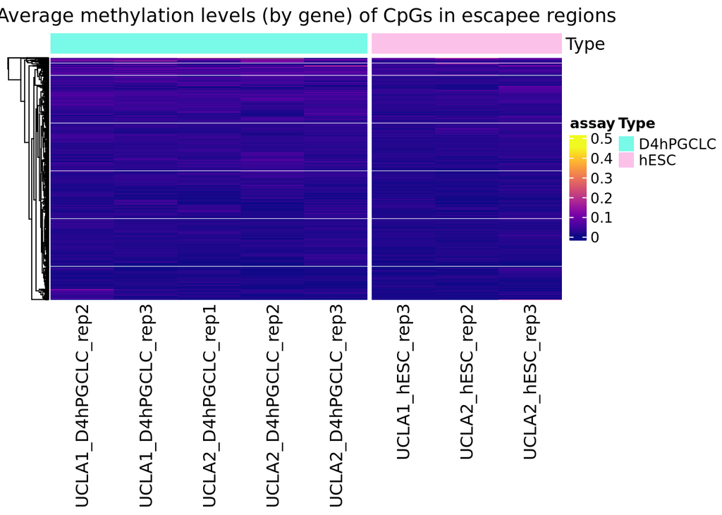

```r
break_coord <- assay(SE) %>% quantile(seq(0,1, by=0.1), na.rm =TRUE)
ExpCols <- viridisLite::plasma(length(seq(break_coord[2], tail(break_coord,1), by=0.05)))
sechm(SE, features = rownames(SE)[1:3000], hmcols=ExpCols, breaks=seq(break_coord[2], tail(break_coord,1), by=0.05), show_rownames=FALSE, show_colnames=TRUE, do.scale=FALSE, column_title = "Average methylation levels (by gene) of CpGs in escapee regions", top_annotation = c("Type"), row_title_rot = 0, cluster_rows = TRUE, gaps_at = "Type")
```

Let’s now show the **median** methylation levels. Instead of plotting for each row an escapee CpGs, I aggregate CpGs by ensembl gene id **doing the median** of the methylation levels.

```r
MedianMeth <- aggregate(assays(bsseq_obj_subset)$Meth_hmC, list(rowData(bsseq_obj_subset)$ensembl_gene_id), median, na.rm = T)
rownames(MedianMeth) <- MedianMeth$Group.1
MedianMeth <- MedianMeth[, -1]

rowDataSE <- rowData(bsseq_obj_subset)
rownames(rowDataSE) <- rowData(bsseq_obj_subset)$ensembl_gene_id
rowDataSE <- rowDataSE[rownames(MedianMeth), ]

SampleAnno <- colData(bsseq_obj_subset)

SE <- SummarizedExperiment(assays=MedianMeth, colData=SampleAnno, rowData = rowDataSE)

identical(colnames(assay(SE)), rownames(colData(SE))) #TRUE
```

```
## [1] TRUE
```

```r
# cellTypes_colors <- c(hiPSCs ="#dd1c77", iMeLCs ="#377eb8", hPGCLCs ="#4daf4a", hEGCLCs = "#ff7f00")
# colData(SE)$Type <- factor(colData(SE)$Type, levels = c("hiPSCs", "iMeLCs" , "hPGCLCs", "hEGCLCs"))
#
# metadata(SE)$anno_colors <- list(Type = cellTypes_colors,
#                                                GenomicRegion = c ("3' UTR" = "#FFADAD", "5' UTR" = "#FFD6A5", "Distal Intergenic" = "#FDFFB6", "Downstream (<=300bp)" = "#FFFFFC", "Exon" = "#9BF6FF", "Intron" = "#A0C4FF", "Promoter (<=1kb)" = "#BDB2FF", "Promoter (1-2kb)" = "#FFC6FF", "Promoter (2-3kb)" = "#CAFFBF"))
```

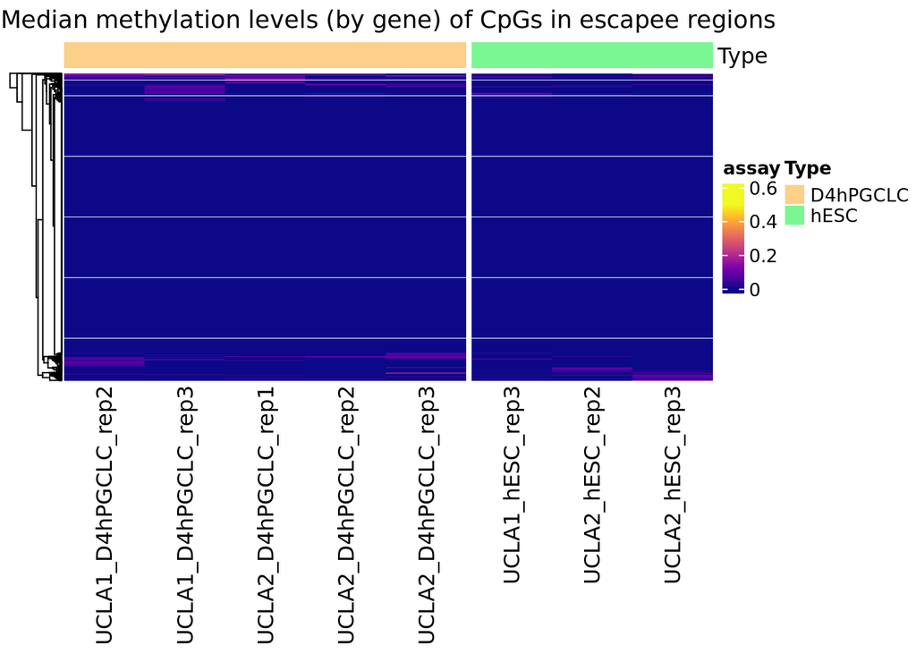

```r
break_coord <- assay(SE) %>% quantile(seq(0,1, by=0.1), na.rm =TRUE)
ExpCols <- viridisLite::plasma(length(seq(head(break_coord,1), tail(break_coord,1), by=0.05)))
sechm(SE, features = rownames(SE)[1:3000], hmcols=ExpCols, breaks=seq(head(break_coord,1), tail(break_coord,1), by=0.05), show_rownames=FALSE, show_colnames=TRUE, do.scale=FALSE, column_title = "Median methylation levels (by gene) of CpGs in escapee regions", top_annotation = c("Type"), row_title_rot = 0, cluster_rows = TRUE, gaps_at = "Type")
```

Let’s change the range of methylation (1st-10th deciles of methylation)

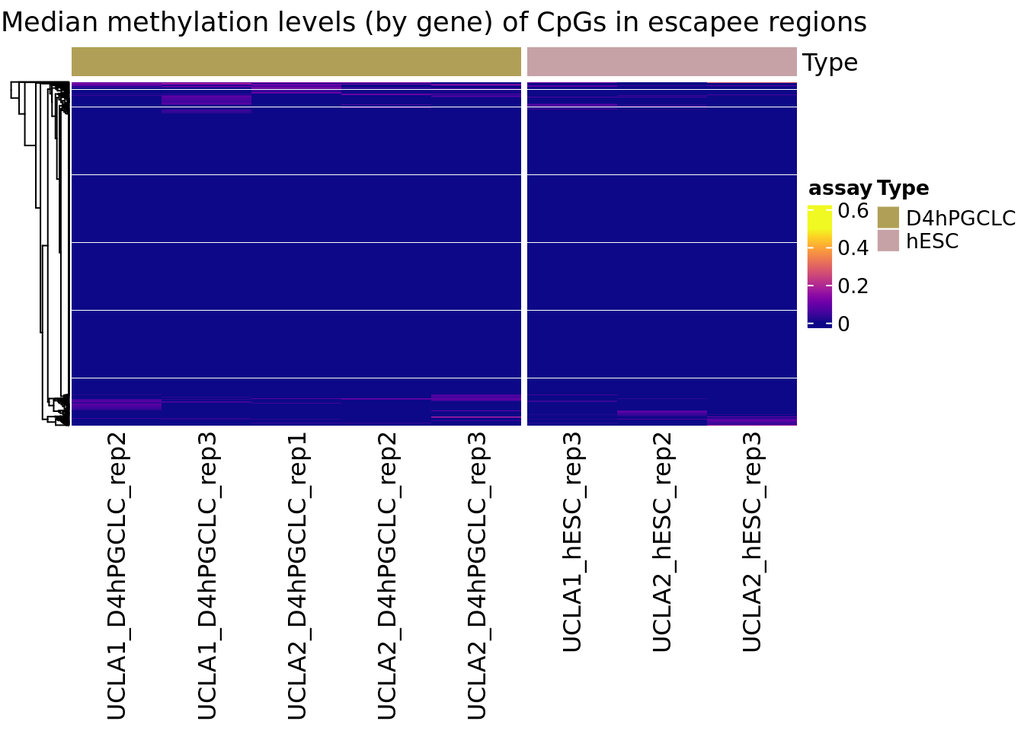

```r
break_coord <- assay(SE) %>% quantile(seq(0,1, by=0.1), na.rm =TRUE)
ExpCols <- viridisLite::plasma(length(seq(break_coord[2], tail(break_coord,1), by=0.05)))
sechm(SE, features = rownames(SE)[1:3000], hmcols=ExpCols, breaks=seq(break_coord[2], tail(break_coord,1), by=0.05), show_rownames=FALSE, show_colnames=TRUE, do.scale=FALSE, column_title = "Median methylation levels (by gene) of CpGs in escapee regions", top_annotation = c("Type"), row_title_rot = 0, cluster_rows = TRUE, gaps_at = "Type")
```

## 3.3 Only 5mCs (WGBS - bACEseq)

```r
AvgMeth <- aggregate(assays(bsseq_obj_subset)$Meth_mC, list(rowData(bsseq_obj_subset)$ensembl_gene_id), mean, na.rm = T)
rownames(AvgMeth) <- AvgMeth$Group.1
AvgMeth <- AvgMeth[, -1]

rowDataSE <- rowData(bsseq_obj_subset)
rownames(rowDataSE) <- rowData(bsseq_obj_subset)$ensembl_gene_id
rowDataSE <- rowDataSE[rownames(AvgMeth), ]

SampleAnno <- colData(bsseq_obj_subset)

SE <- SummarizedExperiment(assays=AvgMeth, colData=SampleAnno, rowData = rowDataSE)

identical(colnames(assay(SE)), rownames(colData(SE))) #TRUE
```

```
## [1] TRUE
```

```r
# cellTypes_colors <- c(hiPSCs ="#dd1c77", iMeLCs ="#377eb8", hPGCLCs ="#4daf4a", hEGCLCs = "#ff7f00")
# colData(SE)$Type <- factor(colData(SE)$Type, levels = c("hiPSCs", "iMeLCs" , "hPGCLCs", "hEGCLCs"))
#
# metadata(SE)$anno_colors <- list(Type = cellTypes_colors,
#                                                GenomicRegion = c ("3' UTR" = "#FFADAD", "5' UTR" = "#FFD6A5", "Distal Intergenic" = "#FDFFB6", "Downstream (<=300bp)" = "#FFFFFC", "Exon" = "#9BF6FF", "Intron" = "#A0C4FF", "Promoter (<=1kb)" = "#BDB2FF", "Promoter (1-2kb)" = "#FFC6FF", "Promoter (2-3kb)" = "#CAFFBF"))
```

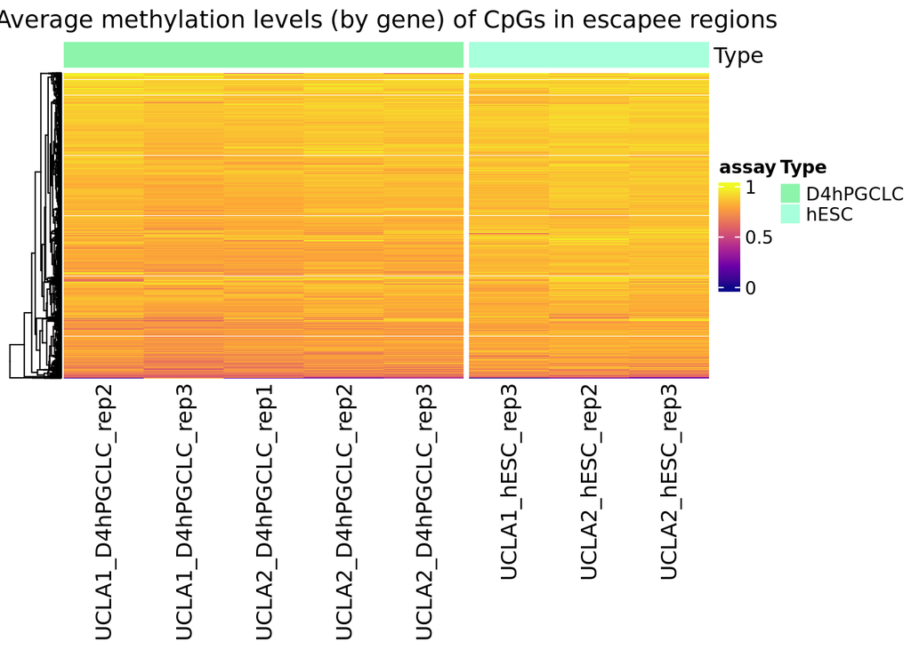

```r
break_coord <- assay(SE) %>% quantile(seq(0,1, by=0.1), na.rm =TRUE)
ExpCols <- viridisLite::plasma(length(seq(head(break_coord,1), tail(break_coord,1), by=0.2)))
sechm(SE, features = rownames(SE)[1:3000], hmcols=ExpCols, breaks=seq(head(break_coord,1), tail(break_coord,1), by=0.2), show_rownames=FALSE, show_colnames=TRUE, do.scale=FALSE, column_title = "Average methylation levels (by gene) of CpGs in escapee regions", top_annotation = c("Type"), row_title_rot = 0, cluster_rows = TRUE, gaps_at = "Type")
```

Let’s change the range of methylation

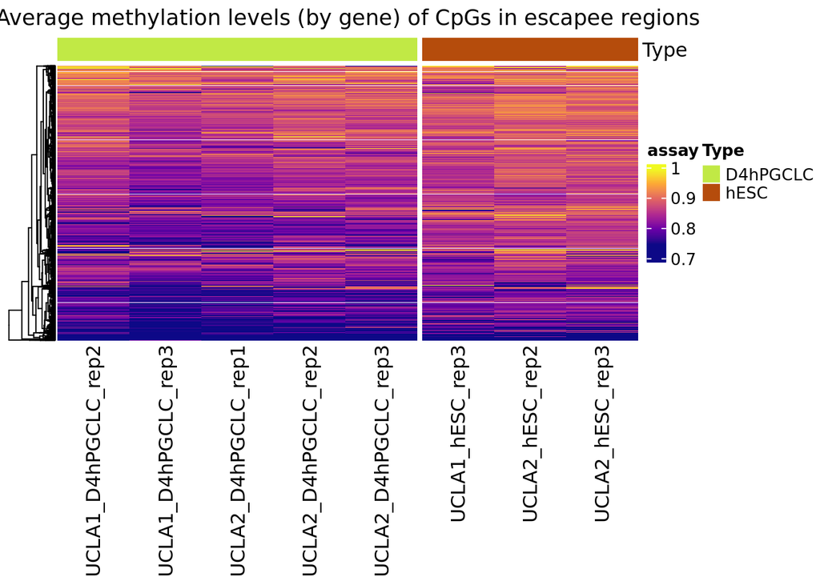

```r
break_coord <- assay(SE) %>% quantile(seq(0,1, by=0.1), na.rm =TRUE)
ExpCols <- viridisLite::plasma(length(seq(break_coord[2], tail(break_coord,1), by=0.05)))
sechm(SE, features = rownames(SE)[1:3000], hmcols=ExpCols, breaks=seq(break_coord[2], tail(break_coord,1), by=0.05), show_rownames=FALSE, show_colnames=TRUE, do.scale=FALSE, column_title = "Average methylation levels (by gene) of CpGs in escapee regions", top_annotation = c("Type"), row_title_rot = 0, cluster_rows = TRUE, gaps_at = "Type")
```

Let’s now show the **median** methylation levels. Instead of plotting for each row an escapee CpGs, I aggregate CpGs by ensembl gene id **doing the median** of the methylation levels.

```r
MedianMeth <- aggregate(assays(bsseq_obj_subset)$Meth_mC, list(rowData(bsseq_obj_subset)$ensembl_gene_id), median, na.rm = T)
rownames(MedianMeth) <- MedianMeth$Group.1
MedianMeth <- MedianMeth[, -1]

rowDataSE <- rowData(bsseq_obj_subset)
rownames(rowDataSE) <- rowData(bsseq_obj_subset)$ensembl_gene_id
rowDataSE <- rowDataSE[rownames(MedianMeth), ]

SampleAnno <- colData(bsseq_obj_subset)

SE <- SummarizedExperiment(assays=MedianMeth, colData=SampleAnno, rowData = rowDataSE)

identical(colnames(assay(SE)), rownames(colData(SE))) #TRUE
```

```
## [1] TRUE
```

```r
# cellTypes_colors <- c(hiPSCs ="#dd1c77", iMeLCs ="#377eb8", hPGCLCs ="#4daf4a", hEGCLCs = "#ff7f00")
# colData(SE)$Type <- factor(colData(SE)$Type, levels = c("hiPSCs", "iMeLCs" , "hPGCLCs", "hEGCLCs"))
#
# metadata(SE)$anno_colors <- list(Type = cellTypes_colors,
#                                                GenomicRegion = c ("3' UTR" = "#FFADAD", "5' UTR" = "#FFD6A5", "Distal Intergenic" = "#FDFFB6", "Downstream (<=300bp)" = "#FFFFFC", "Exon" = "#9BF6FF", "Intron" = "#A0C4FF", "Promoter (<=1kb)" = "#BDB2FF", "Promoter (1-2kb)" = "#FFC6FF", "Promoter (2-3kb)" = "#CAFFBF"))
```

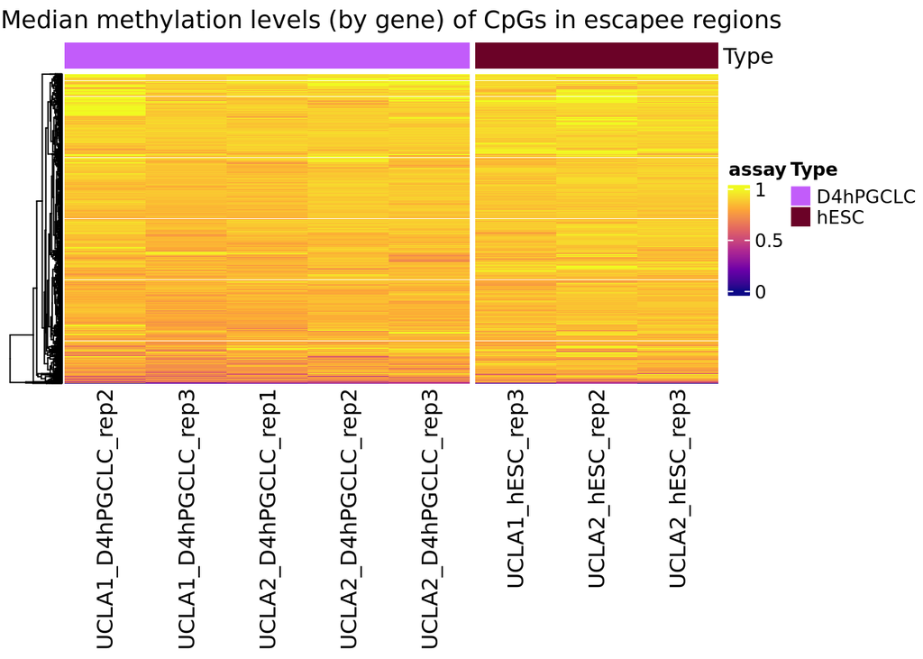

```r
break_coord <- assay(SE) %>% quantile(seq(0,1, by=0.1), na.rm =TRUE)
ExpCols <- viridisLite::plasma(length(seq(head(break_coord,1), tail(break_coord,1), by=0.2)))
sechm(SE, features = rownames(SE)[1:3000], hmcols=ExpCols, breaks=seq(head(break_coord,1), tail(break_coord,1), by=0.2), show_rownames=FALSE, show_colnames=TRUE, do.scale=FALSE, column_title = "Median methylation levels (by gene) of CpGs in escapee regions", top_annotation = c("Type"), row_title_rot = 0, cluster_rows = TRUE, gaps_at = "Type")
```

Let’s change the range of methylation (1st-10th deciles of methylation)

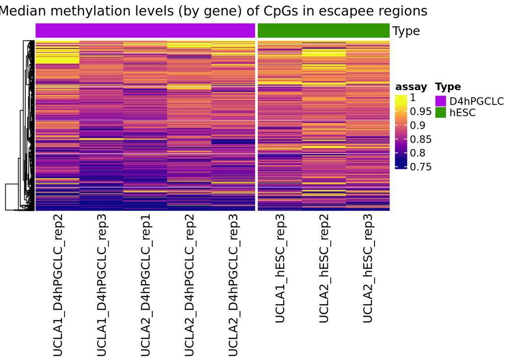

```r
break_coord <- assay(SE) %>% quantile(seq(0,1, by=0.1), na.rm =TRUE)
ExpCols <- viridisLite::plasma(length(seq(break_coord[2], tail(break_coord,1), by=0.05)))
sechm(SE, features = rownames(SE)[1:3000], hmcols=ExpCols, breaks=seq(break_coord[2], tail(break_coord,1), by=0.05), show_rownames=FALSE, show_colnames=TRUE, do.scale=FALSE, column_title = "Median methylation levels (by gene) of CpGs in escapee regions", top_annotation = c("Type"), row_title_rot = 0, cluster_rows = TRUE, gaps_at = "Type")
```

# 4. Session Info

```r
date()
```

```
## [1] "Fri May 23 13:55:55 2025"
```